# Exploring and Analyzing the Effects of Sleep Patterns on College Students

## Team Members

**Hailey Bauer**

Contact Information

**Nolan Nguyen**

Contact Information

# Introduction

College students often have lots of assignments to do, early classes, and many other activities that occupy their time. All of these factors influence their sleep and therefore their mental health, physical health, and academic performance. We strive to discover how these factors influence students through the following research question:

- What is the distribution of sleep quality among college students and are there any significant factors affecting sleep quality (drinking, stress, depression, anxiety, etc.) and is there a correlation between the number of hours slept and cognitive function scores on the skill test?

Let’s explore and answer these questions.

# Prerequisites

Load the following R packages required for the data analysis

```r
library(tidyverse)
```

```r
library(dplyr)
library(ggplot2)
```

# Data Description

First, import the dataset and set it as a variable.

```r
# Read the dataset
SleepStudy <- read.csv("https://raw.githubusercontent.com/haileyb444/datasets/master/SleepStudy.csv")
```

Then, take a random sample of the dataset.

```r
sample_n(SleepStudy, 10)
```

| Gender | ClassYear | LarkOwl | NumEarlyClass | EarlyClass | GPA | ClassesMissed | CognitionZscore | PoorSleepQuality | DepressionScore | AnxietyScore | StressScore | DepressionStatus | AnxietyStatus | Stress | DASScore | Happiness | AlcoholUse | Drinks | WeekdayBed | WeekdayRise | WeekdaySleep | WeekendBed | WeekendRise | WeekendSleep | AverageSleep | AllNighter |
| --- | --- | --- | --- | --- | --- | --- | --- | --- | --- | --- | --- | --- | --- | --- | --- | --- | --- | --- | --- | --- | --- | --- | --- | --- | --- | --- |
| 0 | 3 | Neither | 2 | 1 | 2.77 | 2 | 0.83 | 5 | 4 | 8 | 14 | normal | moderate | normal | 26 | 27 | Light | 10 | 24.75 | 8.50 | 7.75 | 26.63 | 9.75 | 7.13 | 7.57 | 0 |
| 0 | 1 | Neither | 0 | 0 | 3.50 | 2 | -1.17 | 8 | 12 | 7 | 13 | moderate | normal | normal | 32 | 25 | Light | 4 | 26.60 | 9.10 | 7.00 | 26.25 | 8.50 | 5.00 | 6.43 | 0 |
| 0 | 3 | Neither | 2 | 1 | 2.80 | 1 | -0.17 | 8 | 4 | 14 | 12 | normal | moderate | normal | 30 | 27 | Moderate | 6 | 24.10 | 9.25 | 9.05 | 26.50 | 8.25 | 6.00 | 8.18 | 0 |
| 1 | 2 | Lark | 5 | 1 | 3.00 | 0 | -1.18 | 8 | 23 | 12 | 20 | severe | moderate | high | 55 | 24 | Heavy | 12 | 24.00 | 7.90 | 8.50 | 25.50 | 10.50 | 7.50 | 8.22 | 0 |
| 0 | 1 | Neither | 4 | 1 | 3.32 | 5 | 0.19 | 9 | 4 | 4 | 8 | normal | normal | normal | 16 | 25 | Moderate | 9 | 24.55 | 8.28 | 7.73 | 29.00 | 11.00 | 6.00 | 7.24 | 1 |
| 0 | 4 | Neither | 2 | 1 | 2.90 | 0 | -0.04 | 8 | 18 | 12 | 26 | moderate | moderate | high | 56 | 17 | Moderate | 5 | 24.40 | 8.60 | 8.40 | 25.50 | 11.00 | 9.00 | 8.57 | 0 |
| 1 | 2 | Owl | 0 | 0 | 2.50 | 0 | -0.93 | 10 | 11 | 10 | 9 | moderate | moderate | normal | 30 | 29 | Heavy | 15 | 27.30 | 10.40 | 7.10 | 28.50 | 11.00 | 6.50 | 6.93 | 1 |
| 0 | 4 | Lark | 4 | 1 | 3.50 | 0 | 0.19 | 1 | 0 | 1 | 1 | normal | normal | normal | 2 | 35 | Light | 2 | 24.40 | 8.20 | 7.70 | 25.00 | 10.25 | 9.50 | 8.21 | 0 |
| 0 | 3 | Neither | 2 | 1 | 3.20 | 1 | -0.24 | 6 | 2 | 1 | 9 | normal | normal | normal | 12 | 28 | Light | 6 | 26.60 | 8.00 | 5.90 | 26.00 | 10.00 | 6.75 | 6.14 | 0 |
| 0 | 4 | Neither | 2 | 1 | 2.90 | 0 | 0.72 | 2 | 6 | 11 | 31 | normal | moderate | high | 48 | 30 | Moderate | 6 | 26.20 | 8.00 | 6.60 | 25.38 | 10.25 | 6.88 | 6.68 | 0 |

# Exploratory Data Analysis

First to take an initial look at the basic data statistics

```r
summary(SleepStudy)
```

```
##      Gender         ClassYear       LarkOwl          NumEarlyClass
##  Min.   :0.0000   Min.   :1.000   Length:253         Min.   :0.000
##  1st Qu.:0.0000   1st Qu.:2.000   Class :character   1st Qu.:0.000
##  Median :0.0000   Median :2.000   Mode  :character   Median :2.000
##  Mean   :0.4032   Mean   :2.478                      Mean   :1.735
##  3rd Qu.:1.0000   3rd Qu.:3.000                      3rd Qu.:3.000
##  Max.   :1.0000   Max.   :4.000                      Max.   :5.000
##    EarlyClass         GPA        ClassesMissed    CognitionZscore
##  Min.   :0.000   Min.   :2.000   Min.   : 0.000   Min.   :-1.62e+00
##  1st Qu.:0.000   1st Qu.:3.000   1st Qu.: 0.000   1st Qu.:-4.80e-01
##  Median :1.000   Median :3.300   Median : 1.000   Median :-1.00e-02
##  Mean   :0.664   Mean   :3.244   Mean   : 2.209   Mean   :-3.95e-05
##  3rd Qu.:1.000   3rd Qu.:3.500   3rd Qu.: 3.000   3rd Qu.: 4.40e-01
##  Max.   :1.000   Max.   :4.000   Max.   :20.000   Max.   : 1.96e+00
##  PoorSleepQuality DepressionScore   AnxietyScore     StressScore
##  Min.   : 1.000   Min.   : 0.000   Min.   : 0.000   Min.   : 0.000
##  1st Qu.: 4.000   1st Qu.: 1.000   1st Qu.: 1.000   1st Qu.: 3.000
##  Median : 6.000   Median : 3.000   Median : 4.000   Median : 8.000
##  Mean   : 6.257   Mean   : 5.202   Mean   : 5.372   Mean   : 9.466
##  3rd Qu.: 8.000   3rd Qu.: 7.000   3rd Qu.: 8.000   3rd Qu.:14.000
##  Max.   :18.000   Max.   :35.000   Max.   :26.000   Max.   :37.000
##  DepressionStatus   AnxietyStatus         Stress             DASScore
##  Length:253         Length:253         Length:253         Min.   : 0.00
##  Class :character   Class :character   Class :character   1st Qu.: 7.00
##  Mode  :character   Mode  :character   Mode  :character   Median :16.00
##                                                           Mean   :20.04
##                                                           3rd Qu.:28.00
##                                                           Max.   :82.00
##    Happiness      AlcoholUse            Drinks         WeekdayBed
##  Min.   : 0.00   Length:253         Min.   : 0.000   Min.   :21.80
##  1st Qu.:24.00   Class :character   1st Qu.: 3.000   1st Qu.:24.20
##  Median :28.00   Mode  :character   Median : 5.000   Median :24.80
##  Mean   :26.11                      Mean   : 5.569   Mean   :24.85
##  3rd Qu.:30.00                      3rd Qu.: 8.000   3rd Qu.:25.50
##  Max.   :35.00                      Max.   :24.000   Max.   :29.10
##   WeekdayRise      WeekdaySleep      WeekendBed     WeekendRise
##  Min.   : 5.500   Min.   : 3.000   Min.   :21.50   Min.   : 5.25
##  1st Qu.: 8.000   1st Qu.: 7.200   1st Qu.:24.88   1st Qu.: 9.25
##  Median : 8.500   Median : 7.950   Median :25.50   Median :10.25
##  Mean   : 8.586   Mean   : 7.866   Mean   :25.58   Mean   :10.20
##  3rd Qu.: 9.150   3rd Qu.: 8.600   3rd Qu.:26.25   3rd Qu.:11.00
##  Max.   :12.020   Max.   :10.970   Max.   :30.25   Max.   :15.00
##   WeekendSleep     AverageSleep      AllNighter
##  Min.   : 4.000   Min.   : 4.950   Min.   :0.0000
##  1st Qu.: 7.250   1st Qu.: 7.430   1st Qu.:0.0000
##  Median : 8.250   Median : 8.000   Median :0.0000
##  Mean   : 8.217   Mean   : 7.966   Mean   :0.1344
##  3rd Qu.: 9.250   3rd Qu.: 8.590   3rd Qu.:0.0000
##  Max.   :12.750   Max.   :10.620   Max.   :1.0000
```

Through our preliminary observations of the `SleepStudy` dataset we noticed that several variables were hard to understand at first glance, were not all formatted in the same manner, and one variable should be classified as a character value instead of an integer for data analysis purposes. We used the following code to conduct this data cleaning process, ultimately improving the readability of the dataset.

```r
# Replace the indicator values in various columns so as to create an easier to read dataset.
SleepStudy["Gender"][SleepStudy["Gender"] == 0] <- "F"

SleepStudy["Gender"][SleepStudy["Gender"] == 1] <- "M"

SleepStudy["EarlyClass"][SleepStudy["EarlyClass"] == 0] <- "No"

SleepStudy["EarlyClass"][SleepStudy["EarlyClass"] == 1] <- "Yes"

SleepStudy["AllNighter"][SleepStudy["AllNighter"] == 0] <- "No"

SleepStudy["AllNighter"][SleepStudy["AllNighter"] == 1] <- "Yes"


# Change variables to be the same throughout
SleepStudy[SleepStudy == "moderate"] <- "Moderate"

SleepStudy[SleepStudy == "normal"] <- "Normal"

SleepStudy[SleepStudy == "severe"] <- "Severe"

SleepStudy[SleepStudy == "high"] <- "High"

# Set the Class Year column as a character value
SleepStudy$ClassYear <- as.character(SleepStudy$ClassYear)

# Print a sample of the improved dataframe
sample_n(SleepStudy, 10)
```

| Gender | ClassYear | LarkOwl | NumEarlyClass | EarlyClass | GPA | ClassesMissed | CognitionZscore | PoorSleepQuality | DepressionScore | AnxietyScore | StressScore | DepressionStatus | AnxietyStatus | Stress | DASScore | Happiness | AlcoholUse | Drinks | WeekdayBed | WeekdayRise | WeekdaySleep | WeekendBed | WeekendRise | WeekendSleep | AverageSleep | AllNighter |
| --- | --- | --- | --- | --- | --- | --- | --- | --- | --- | --- | --- | --- | --- | --- | --- | --- | --- | --- | --- | --- | --- | --- | --- | --- | --- | --- |
| M | 4 | Neither | 0 | No | 3.60 | 1 | -0.03 | 6 | 10 | 11 | 18 | Moderate | Moderate | High | 39 | 29 | Light | 2 | 24.30 | 7.80 | 7.70 | 23.50 | 9.00 | 9.00 | 8.07 | No |
| M | 3 | Neither | 0 | No | 3.90 | 4 | 0.52 | 6 | 4 | 2 | 7 | Normal | Normal | Normal | 13 | 24 | Heavy | 12 | 25.60 | 9.85 | 8.85 | 25.00 | 10.75 | 8.25 | 8.68 | No |
| F | 2 | Neither | 0 | No | 3.72 | 1 | 1.45 | 4 | 4 | 1 | 8 | Normal | Normal | Normal | 13 | 29 | Light | 3 | 25.34 | 8.16 | 8.03 | 27.00 | 10.25 | 7.50 | 7.88 | No |
| F | 2 | Lark | 1 | Yes | 3.40 | 0 | 1.71 | 2 | 0 | 4 | 4 | Normal | Normal | Normal | 8 | 31 | Light | 2 | 23.55 | 8.20 | 9.20 | 24.00 | 8.88 | 7.50 | 8.71 | No |
| F | 2 | Owl | 2 | Yes | 3.60 | 3 | 0.52 | 5 | 2 | 3 | 6 | Normal | Normal | Normal | 11 | 30 | Moderate | 4 | 25.60 | 8.43 | 7.33 | 26.50 | 12.00 | 8.25 | 7.59 | No |
| F | 2 | Neither | 5 | Yes | 3.20 | 2 | 0.03 | 5 | 0 | 1 | 5 | Normal | Normal | Normal | 6 | 31 | Light | 6 | 24.40 | 7.75 | 7.95 | 25.00 | 10.50 | 8.00 | 7.96 | No |
| F | 3 | Neither | 2 | Yes | 2.77 | 2 | 0.83 | 5 | 4 | 8 | 14 | Normal | Moderate | Normal | 26 | 27 | Light | 10 | 24.75 | 8.50 | 7.75 | 26.63 | 9.75 | 7.13 | 7.57 | No |
| F | 4 | Neither | 3 | Yes | 3.10 | 10 | -0.37 | 3 | 3 | 2 | 5 | Normal | Normal | Normal | 10 | 31 | Light | 3 | 24.10 | 8.90 | 8.90 | 26.00 | 12.50 | 10.25 | 9.29 | No |
| M | 2 | Neither | 0 | No | 3.40 | 0 | -1.06 | 9 | 10 | 3 | 8 | Moderate | Normal | Normal | 21 | 25 | Light | 4 | 25.90 | 8.65 | 7.05 | 25.50 | 9.75 | 7.50 | 7.18 | No |
| M | 3 | Owl | 3 | Yes | 2.80 | 20 | -0.57 | 15 | 6 | 5 | 10 | Normal | Normal | Normal | 21 | 19 | Moderate | 7 | 25.25 | 8.12 | 7.20 | 25.67 | 10.50 | 8.00 | 7.43 | No |

## Univariate Exploration

Initiating the univariate exploration of the `SleepStudy` dataframe marks the commencement of a nuanced journey into the intricate realm of sleep patterns among the surveyed individuals. As we initiate this phase of analysis, we focus on individual variables, with the goal of comprehensively understanding their distributions, trends, and inherent characteristics. In this exploration, we strive to investigate each variable, unraveling the singular story encapsulated within the data.

### Sleep Quality

In the realm of sleep study research, the variable `PoorSleepQuality` within the `SleepStudy` dataframe serves as a crucial metric, encapsulating the diverse experiences of surveyed college students. Representing a quantitative measure of sleep quality, this variable unveils a spectrum of data points where higher values correspond to poorer sleep quality. As we delve into the intricate details of this dataset, we gain valuable insights into the sleep patterns of college students, shedding light on the factors influencing their sleep quality and laying the foundation for a comprehensive analysis of the relationship between various variables and the overall well-being of these individuals.

The histogram below depicts the distribution of the quality of sleep among college students. The data in this graph is primarily centered around 5 with observations on either end of the spectrum as well. This indicates that most college students get an average to poor quality of sleep.

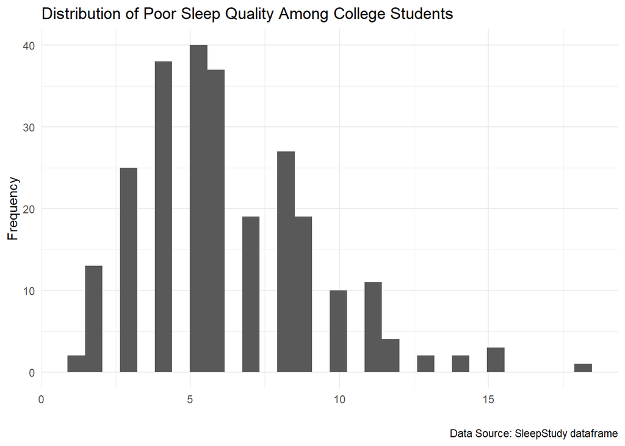

```r
SleepStudy %>%
  ggplot() +
  geom_histogram(aes(x = PoorSleepQuality)) +
  theme_minimal() +
  labs(x = "",
       y = "Frequency",
       caption = "Data Source: SleepStudy dataframe",
       title = "Distribution of Poor Sleep Quality Among College Students")
```

### Demographics

The next step involves scrutinizing pertinent demographic variables, including gender, class year, and sleep habits, to understand their distribution within the surveyed college student population. This analysis aims to uncover patterns and relationships among these key factors.

#### Gender

Now, we turn our attention specifically to the variable `Gender` within the surveyed college student population. This entails a detailed exploration of the distribution of gender categories to gain a comprehensive understanding of the demographic landscape. Analyzing gender patterns contributes valuable insights into potential disparities or trends within the dataset.

Notice that among the surveyed college students, there is an increased population of females compared to males. However, this population difference is not significant enough to cause the data to be skewed.

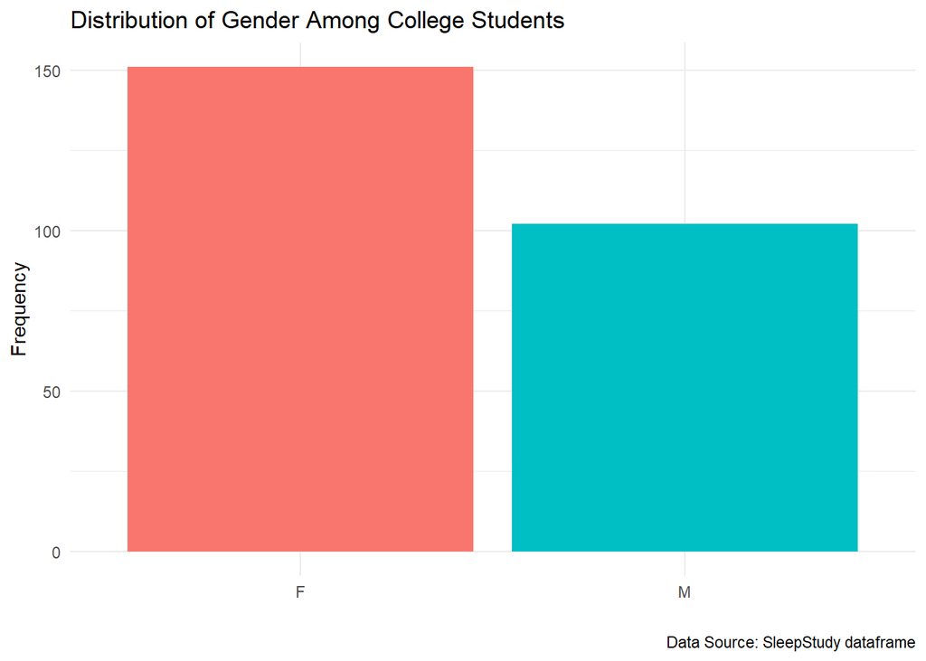

```r
ggplot(data = SleepStudy) +
  geom_bar(aes(x = Gender, fill = Gender)) +
  theme_minimal() +
  theme(legend.position = "none") +
  labs(x = "",
       y = "Frequency",
       caption = "Data Source: SleepStudy dataframe",
       title = "Distribution of Gender Among College Students")
```

#### ClassYear

The following analysis will concentrate on the variable “class year,” exploring its distribution among surveyed college students. This focused investigation intends to reveal insights into the demographic composition within each academic level, thereby enhancing our comprehension of potential trends or variations within the dataset.

Notice that while the populations within the `ClassYear` variable are relatively similar, there is a significant increase in the population in the second years. Should these individuals have particular habits or interests, this may influence the data more than another observation in the first, third, or fourth years.

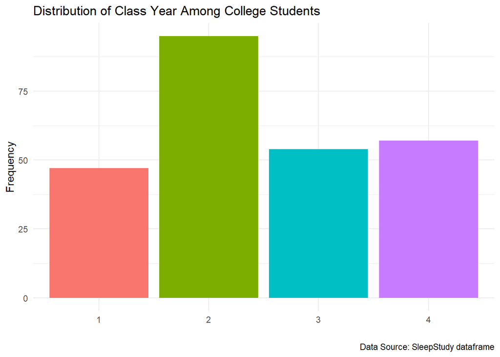

```r
ggplot(data = SleepStudy) +
  geom_bar(aes(x = ClassYear, fill = ClassYear)) +
  theme_minimal() +
  theme(legend.position = "none") +
  labs(x = "",
       y = "Frequency",
       caption = "Data Source: SleepStudy dataframe",
       title = "Distribution of Class Year Among College Students")
```

#### Sleep Habits

Now directing our attention to the variable `LarkOwl`, a categorical attribute indicating whether an individual identifies as a morning person (Lark), a night owl, or neither. The analysis will delve into the distribution of these sleep habits among surveyed college students. By understanding how individuals categorize their sleep preferences, this examination aims to uncover patterns and variations in sleep habits within the dataset.

Notice that most surveyed students were considered neither, while the populations of those considered Larks or Owls were about the same. This graph may indicate that the `Lark` and `Owl` populations may experience different variations within the dataset compared to those that are not within these populations.

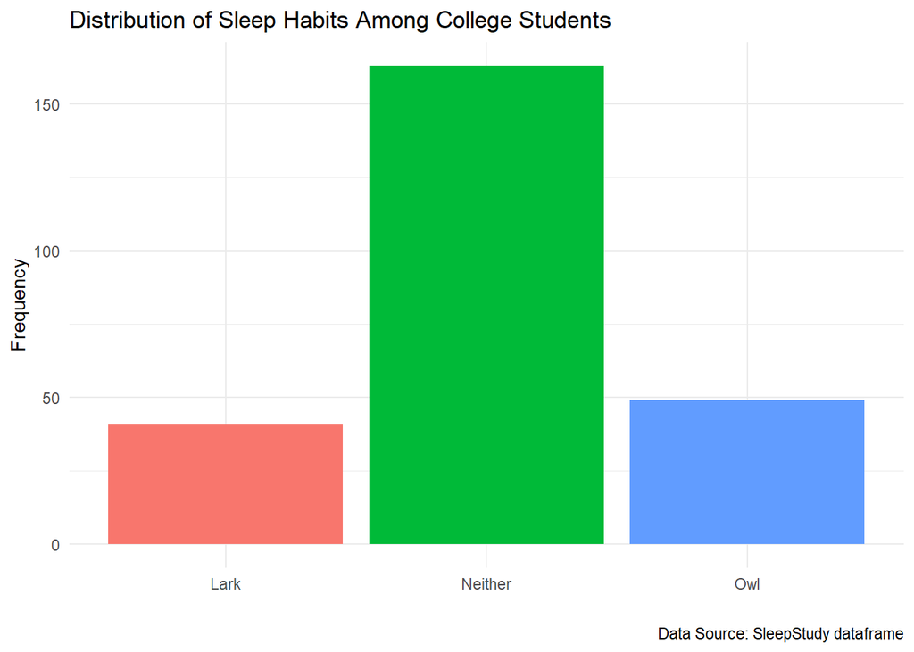

```r
SleepStudy %>%
  ggplot() +
  geom_bar(aes(x = LarkOwl, fill = LarkOwl)) +
  theme_minimal() +
  theme(legend.position = "none") +
  labs(x = "",
       y = "Frequency",
       caption = "Data Source: SleepStudy dataframe",
       title = "Distribution of Sleep Habits Among College Students")
```

### Mental Health Factors

Shifting the focus specifically to the distribution of mental health factors, the analysis will delve into the prevalence and patterns of variables related to stress, depression, and anxiety among surveyed college students.

#### Depression

Now, honing in on the specific variables `DepressionScore` and `DepressionStatus`, the analysis will delve into the distribution of depression scores and levels among surveyed college students. This examination aims to reveal how individuals are distributed across different categories or levels of depression, shedding light on the prevalence and intensity of depressive experiences within the dataset.

Notice that the distribution of depression among college students lessens as the depression status worsens, indicating that not many of the surveyed students experienced severe depression. As the depression score increases, the status worsens as seen in the graph.

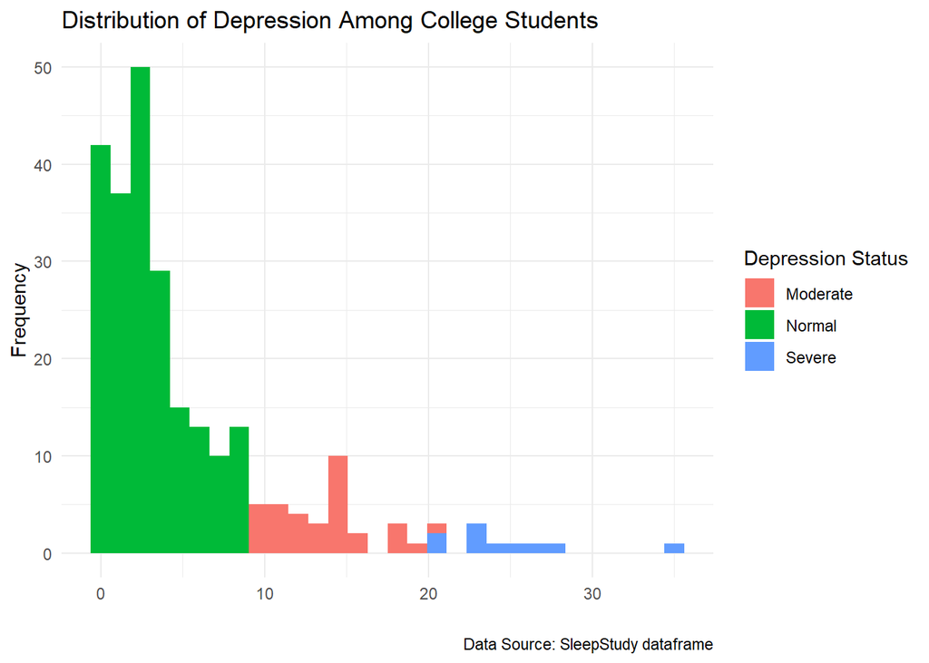

```r
ggplot(data = SleepStudy) +
  geom_histogram(aes(x = DepressionScore, fill = DepressionStatus)) +
  theme_minimal() +
  labs(x = "",
       y = "Frequency",
       fill = "Depression Status",
       caption = "Data Source: SleepStudy dataframe",
       title = "Distribution of Depression Among College Students")
```

#### Anxiety

The forthcoming analysis zeroes in on the variable `AnxietyStatus` and `AnxietyScore`, delving into its distribution among surveyed college students. This exploration seeks to unveil patterns and prevalence levels related to anxious experiences, offering valuable insights into the mental health dynamics within the dataset.

Notice that, similar to depression, the distribution of anxiety among college students lessens as the anxiety status worsens. Additionally, as the axiety score increases, the status worsens as seen in the graph.

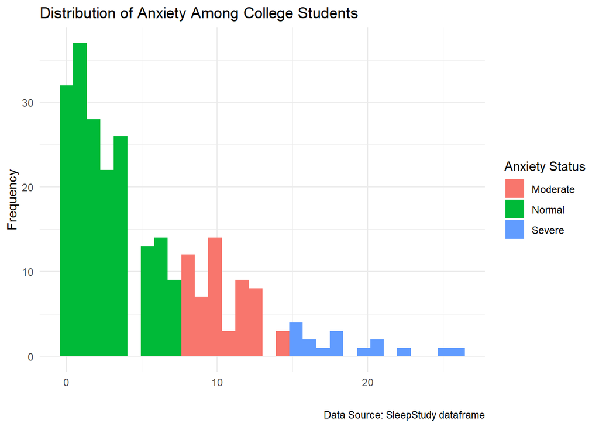

```r
ggplot(data = SleepStudy) +
  geom_histogram(aes(x = AnxietyScore, fill = AnxietyStatus)) +
  theme_minimal() +
  labs(x = "",
       y = "Frequency",
       fill = "Anxiety Status",
       caption = "Data Source: SleepStudy dataframe",
       title = "Distribution of Anxiety Among College Students")
```

#### Stress

Directing our focus to the variables `Stress` and `StressScore`, the analysis will thoroughly explore the distribution of stress levels among surveyed college students. This examination aims to uncover how individuals are distributed across different categories or levels of stress, providing insights into the prevalence and varying degrees of stress experiences within the dataset.

Notice that while the majority of the surveyed population lies within the normal level of stress, there is a significant quantity of individuals with high stress levels. Furthermore, as the stress score increases, the level worsens as seen in the graph.

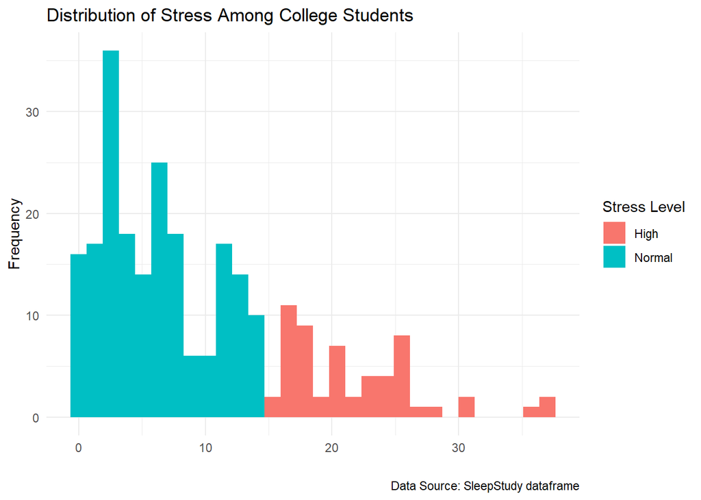

```r
ggplot(data = SleepStudy) +
  geom_histogram(aes(x = StressScore, fill = Stress)) +
  theme_minimal() +
  labs(x = "",
       y = "Frequency",
       fill = "Stress Level",
       caption = "Data Source: SleepStudy dataframe",
       title = "Distribution of Stress Among College Students")
```

### Alcohol

The forthcoming analysis will center on the variables`AlcoholUse` and `Drinks`, exploring its distribution among surveyed college students. This investigation seeks to unveil patterns and prevalence levels related to drinking habits, offering valuable insights into behaviors associated with alcohol use within the dataset.

Note that the students in the sleep survey self-reported their level of alcohol use (`AlcoholUse`). This causes variations to occur as each individual’s understanding and criteria for the labels differ. For example, one student reported their alcohol use as “light” while stating that they drank an average of 24 alcoholic beverages per week while another student reported their alcohol use as “heavy” while drinking an average of 5 alcoholic beverages per week.

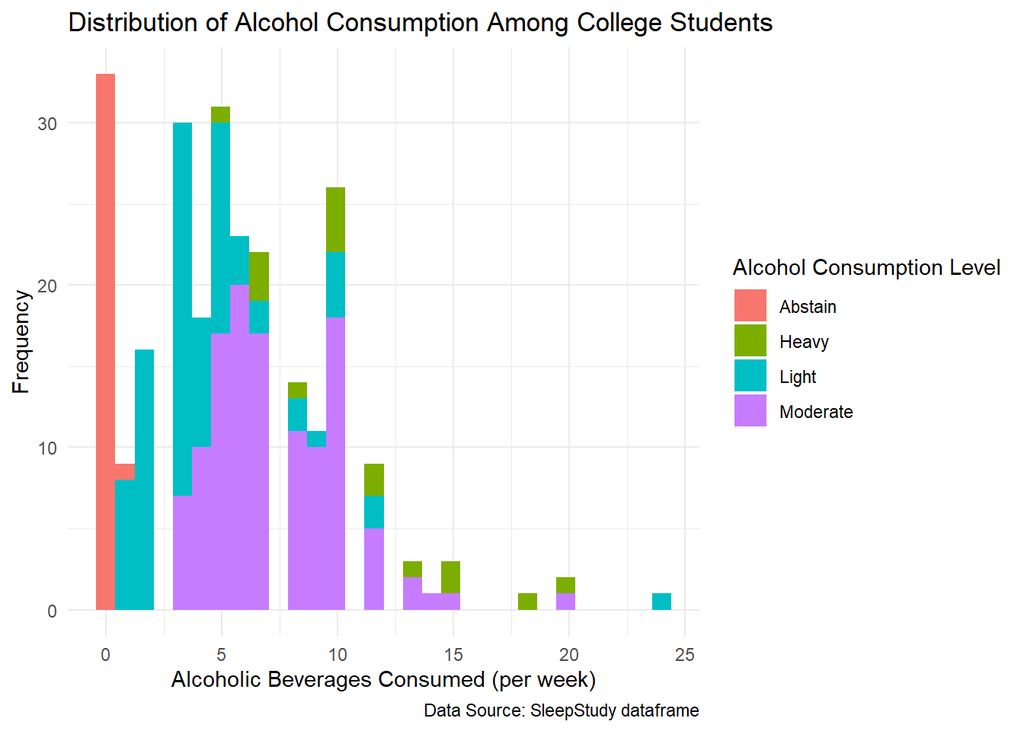

```r
ggplot(data = SleepStudy) +
  geom_histogram(aes(x = Drinks, fill = AlcoholUse)) +
  theme_minimal() +
  labs(x = "Alcoholic Beverages Consumed (per week)",
       y = "Frequency",
       fill = "Alcohol Consumption Level",
       caption = "Data Source: SleepStudy dataframe",
       title = "Distribution of Alcohol Consumption Among College Students")
```

We have standardized these labels as it relates to the dataset so as to provide a more accurate result for the distribution of alcoholic beverages consumed on a weekly basis by college students and their drinking significance labels.

```r
# Create a new dataset with the refined drinking significance labels
AlcoholUse_Refined <- SleepStudy %>%
  mutate(AlcoholUse_Refined = ifelse(Drinks == 0, "Abstain",
                                     ifelse(Drinks <= 5, "Light",
                                            ifelse(Drinks <= 9, "Moderate", "Heavy"))))
AlcoholUse_Refined
```

| Gender | ClassYear | LarkOwl | NumEarlyClass | EarlyClass | GPA | ClassesMissed | CognitionZscore | PoorSleepQuality | DepressionScore | AnxietyScore | StressScore | DepressionStatus | AnxietyStatus | Stress | DASScore | Happiness | AlcoholUse | Drinks | WeekdayBed | WeekdayRise | WeekdaySleep | WeekendBed | WeekendRise | WeekendSleep | AverageSleep | AllNighter | AlcoholUse_Refined |
| --- | --- | --- | --- | --- | --- | --- | --- | --- | --- | --- | --- | --- | --- | --- | --- | --- | --- | --- | --- | --- | --- | --- | --- | --- | --- | --- | --- |
| F | 4 | Neither | 0 | No | 3.60 | 0 | -0.26 | 4 | 4 | 3 | 8 | Normal | Normal | Normal | 15 | 28 | Moderate | 10 | 25.75 | 8.70 | 7.70 | 25.75 | 9.50 | 5.88 | 7.18 | No | Heavy |
| F | 4 | Neither | 2 | Yes | 3.24 | 0 | 1.39 | 6 | 1 | 0 | 3 | Normal | Normal | Normal | 4 | 25 | Moderate | 6 | 25.70 | 8.20 | 6.80 | 26.00 | 10.00 | 7.25 | 6.93 | No | Moderate |
| F | 4 | Owl | 0 | No | 2.97 | 12 | 0.38 | 18 | 18 | 18 | 9 | Moderate | Severe | Normal | 45 | 17 | Light | 3 | 27.44 | 6.55 | 3.00 | 28.00 | 12.59 | 10.09 | 5.02 | No | Light |
| F | 1 | Lark | 5 | Yes | 3.76 | 0 | 1.39 | 9 | 1 | 4 | 6 | Normal | Normal | Normal | 11 | 32 | Light | 2 | 23.50 | 7.17 | 6.77 | 27.00 | 8.00 | 7.25 | 6.90 | No | Light |
| F | 4 | Owl | 0 | No | 3.20 | 4 | 1.22 | 9 | 7 | 25 | 14 | Normal | Severe | Normal | 46 | 15 | Moderate | 4 | 25.90 | 8.67 | 6.09 | 23.75 | 9.50 | 7.00 | 6.35 | No | Light |
| M | 4 | Neither | 0 | No | 3.50 | 0 | -0.04 | 6 | 14 | 8 | 28 | Moderate | Moderate | High | 50 | 22 | Abstain | 0 | 23.80 | 8.95 | 9.05 | 26.00 | 10.75 | 9.00 | 9.04 | No | Abstain |
| M | 2 | Lark | 2 | Yes | 3.35 | 2 | 0.41 | 2 | 1 | 0 | 1 | Normal | Normal | Normal | 2 | 25 | Moderate | 6 | 25.35 | 8.48 | 7.73 | 25.63 | 10.13 | 7.00 | 7.52 | Yes | Moderate |
| F | 2 | Lark | 0 | No | 3.00 | 0 | -0.59 | 10 | 2 | 2 | 3 | Normal | Normal | Normal | 7 | 29 | Light | 3 | 23.90 | 9.07 | 9.02 | 25.13 | 9.75 | 9.00 | 9.01 | No | Light |
| F | 1 | Neither | 2 | Yes | 4.00 | 0 | 1.03 | 5 | 12 | 16 | 20 | Moderate | Severe | High | 48 | 29 | Light | 3 | 24.40 | 8.75 | 8.25 | 24.00 | 9.00 | 9.25 | 8.54 | No | Light |
| F | 4 | Neither | 2 | Yes | 2.90 | 0 | 0.72 | 2 | 6 | 11 | 31 | Normal | Moderate | High | 48 | 30 | Moderate | 6 | 26.20 | 8.00 | 6.60 | 25.38 | 10.25 | 6.88 | 6.68 | No | Moderate |

[output cut: 243 more lines]

Below illustrates the alcohol distribution among the surveyed college students using the standardized `AlcoholUse_Refined` variable so as to provide more a accurate analysis and depiction of the dataset.

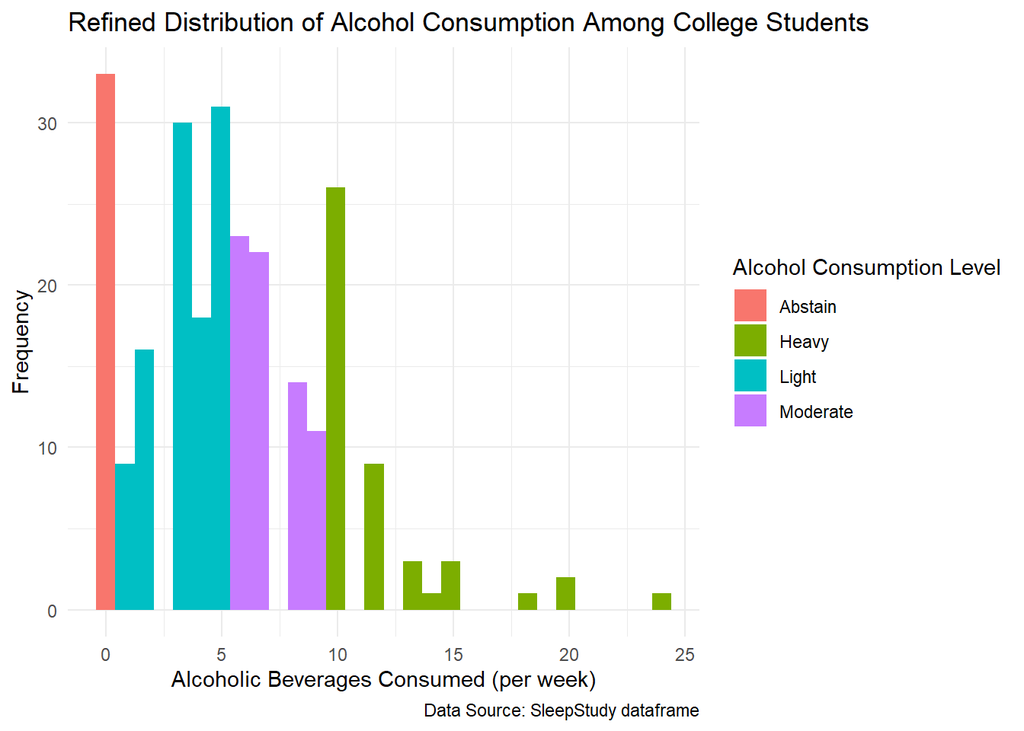

```r
ggplot(data = AlcoholUse_Refined) +
  geom_histogram(aes(x = Drinks, fill = AlcoholUse_Refined)) +
  theme_minimal() +
  labs(x = "Alcoholic Beverages Consumed (per week)",
       y = "Frequency",
       fill = "Alcohol Consumption Level",
       caption = "Data Source: SleepStudy dataframe",
       title = "Refined Distribution of Alcohol Consumption Among College Students")
```

## Multivariate Exploration

Commencing the multivariate exploration within the `SleepStudy` dataframe denotes a significant phase in our analyses. Unlike the solitary focus of univariate analysis, this phase allows us to navigate the intricate relationships between numerous variables. As we delve into the complexities of these interconnected factors, our goal is to unearth hidden patterns and correlations that collectively influence sleep-related behaviors within the surveyed population.

### Sleep Quality by Significant Factors

Shifting our focus to sleep quality by significant factors. Looking at gender distribution as well as class year demographics we get a glimpse on the landscape of college students’ sleep experiences. With a further exploration into mental health factors, it reveals an intricate relationship between depression, anxiety, and stress, and sleep quality. Our analysis extends to alcohol consumption, academic performance metrics like GPA and class attendance, and even diving into all-nighters, unraveling their impact on sleep quality. Additionally, the investigation explores the correlation between the quantity of sleep and cognitive function scores, providing insights into the complex relationship between sleep duration and academic performance. This understanding serves as a foundation for informed strategies aimed at developing improved well-being and academic success among college students.

#### Demographics

As for our demographic analysis in our exploration of college students’ sleep quality we investigate gender, class year, and sleep habits as shown below to unveil any intriguing patterns.

##### Gender

The distribution of `PoorSleepQuality` is explored in relation to `Gender` among college students. Our analysis reveals that there is no significant difference in sleep quality between male and female students. The boxplot illustrates that the median `PoorSleepQuality` scores are comparable, indicating that gender alone may not be a strong predictor of sleep disturbances.

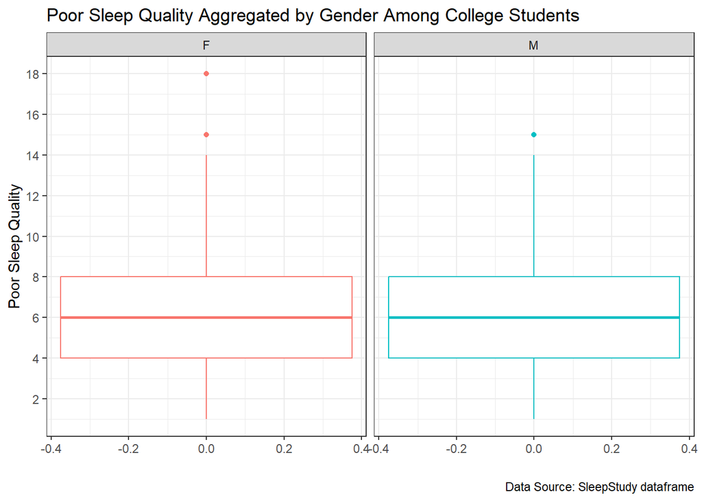

```r
SleepStudy %>%
  ggplot() +
  geom_boxplot(aes(y = PoorSleepQuality, color = Gender)) +
  scale_y_continuous(breaks = seq(0, 20, by = 2)) +
  facet_wrap(vars(Gender)) +
  theme_bw() +
  theme(legend.position = "none") +
  labs(x = "",
       y = "Poor Sleep Quality",
       caption = "Data Source: SleepStudy dataframe",
       title = "Poor Sleep Quality Aggregated by Gender Among College Students")
```

##### Class Year

Further delving into demographic factors, we analyze the relationship between `ClassYear` and `PoorSleepQuality`. Surprisingly, there is no distinct pattern across class years, suggesting that sleep quality is not strongly associated with academic progression. The boxplot displays similar median Poor Sleep Quality scores across each of the different class years.

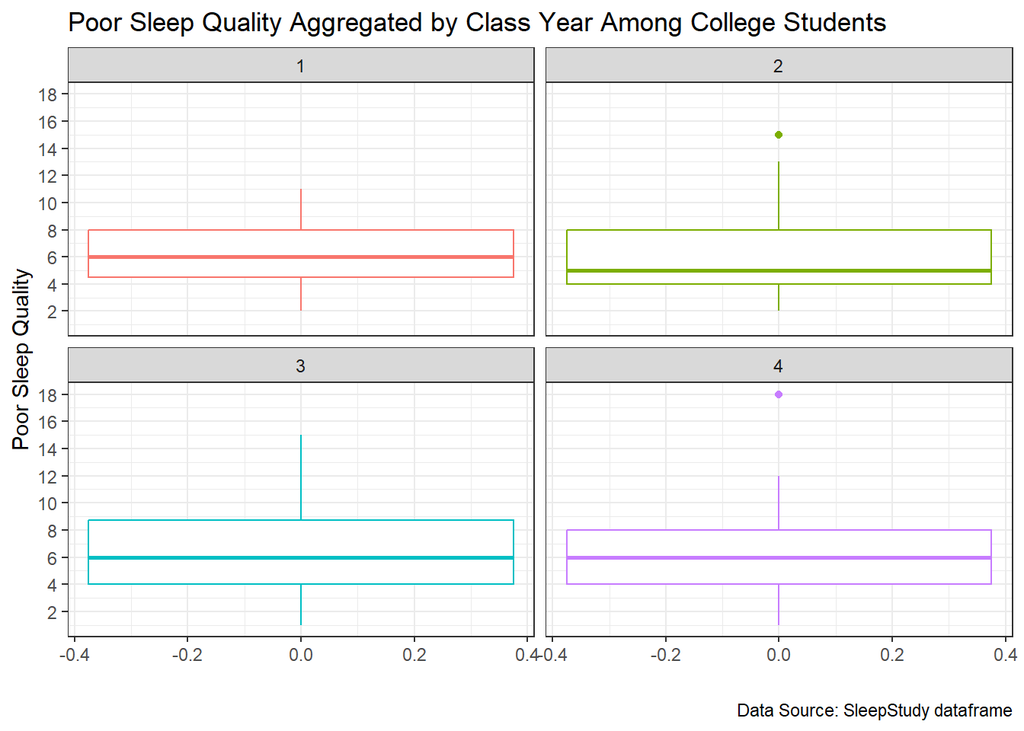

```r
SleepStudy %>%
  ggplot() +
  geom_boxplot(aes(y = PoorSleepQuality, color = ClassYear)) +
  scale_y_continuous(breaks = seq(0, 20, by = 2)) +
  facet_wrap(vars(ClassYear)) +
  theme_bw() +
  theme(legend.position = "none")+
  labs(x = "",
       y = "Poor Sleep Quality",
       caption = "Data Source: SleepStudy dataframe",
       title = "Poor Sleep Quality Aggregated by Class Year Among College Students")
```

##### Sleep Habits

Examining sleep habits, we investigate the impact of the tendency of individuals being a morning person (Lark), night owl, or neither on `PoorSleepQuality`. The boxplot indicates that students who are considered night owls tend to have slightly poorer sleep quality, with a noticeable shift in the median scores. This suggests a potential connection between the sleep habits and sleep disturbances among college students.

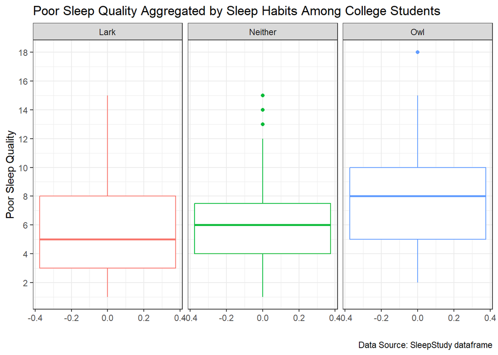

```r
SleepStudy %>%
  ggplot() +
  geom_boxplot(aes(y = PoorSleepQuality, color = LarkOwl)) +
  scale_y_continuous(breaks = seq(0, 20, by = 2)) +
  facet_wrap(vars(LarkOwl)) +
  theme_bw() +
  theme(legend.position = "none") +
  labs(x = "",
       y = "Poor Sleep Quality",
       caption = "Data Source: SleepStudy dataframe",
       title = "Poor Sleep Quality Aggregated by Sleep Habits Among College Students")
```

#### Mental Health Factors

In our investigation of college students’ sleep quality, a key focus is on mental health factors, specifically stress, anxiety, and depression. This analysis aims to uncover potential correlations and patterns between mental health indicators and sleep disturbances. As we delve into these factors, our goal is to understand the interplay between mental well-being and sleep quality, offering valuable insights into the complex relationships that contribute to the overall health of college students.

##### Depression

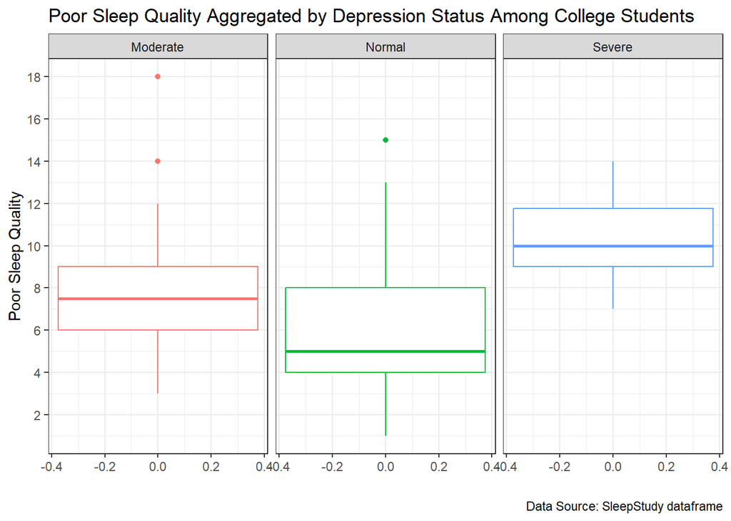

```r
SleepStudy %>%
  ggplot() +
  geom_boxplot(aes(y = PoorSleepQuality, color = DepressionStatus)) +
  scale_y_continuous(breaks = seq(0, 20, by = 2)) +
  facet_wrap(vars(DepressionStatus)) +
  theme_bw() +
  theme(legend.position = "none") +
  labs(x = "",
       y = "Poor Sleep Quality",
       caption = "Data Source: SleepStudy dataframe",
       title = "Poor Sleep Quality Aggregated by Depression Status Among College Students")
```

A scatter plot and regression line further emphasize this relationship, showing a positive correlation between `DepressionScore` and `PoorSleepQuality` of approximately 0.434.

```r
cor.test(SleepStudy$PoorSleepQuality, SleepStudy$DepressionScore)
```

```
##
##  Pearson's product-moment correlation
##
## data:  SleepStudy$PoorSleepQuality and SleepStudy$DepressionScore
## t = 7.6254, df = 251, p-value = 5.02e-13
## alternative hypothesis: true correlation is not equal to 0
## 95 percent confidence interval:
##  0.3279023 0.5287396
## sample estimates:
##      cor
## 0.433692
```

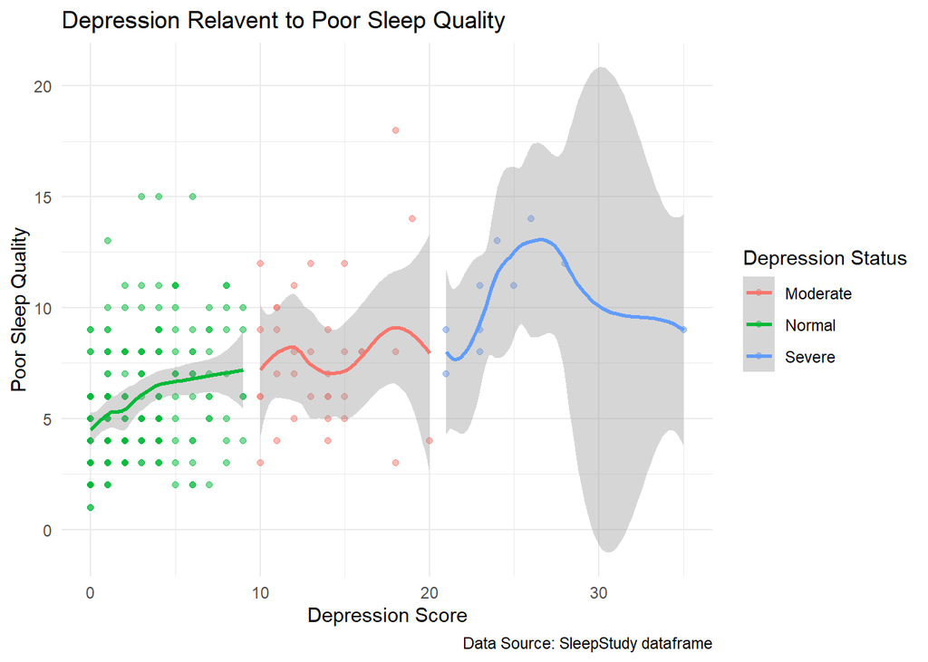

```r
ggplot(SleepStudy, aes(x = DepressionScore, y = PoorSleepQuality, color = DepressionStatus)) +
  geom_point(alpha = 0.5) +
  geom_smooth() +
  theme_minimal() +
  labs(x = "Depression Score",
       y = "Poor Sleep Quality",
       color ="Depression Status",
       caption = "Data Source: SleepStudy dataframe",
       title = "Depression Relavent to Poor Sleep Quality")
```

##### Anxiety

The exploration extends to anxiety, where we examine how `AnxietyStatus` influence `PoorSleepQuality`. With a glance at the side-by-side boxplots below there is an evident trend where as the anxiety level increases the poor sleep quality also increases. This suggests a strong correlation with a higher anxiety score and deficiency of quality of sleep.

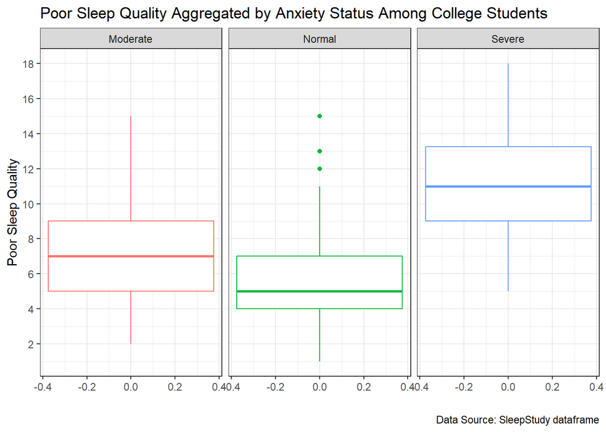

```r
SleepStudy %>%
  ggplot() +
  geom_boxplot(aes(y = PoorSleepQuality, color = AnxietyStatus)) +
  scale_y_continuous(breaks = seq(0, 20, by = 2)) +
  facet_wrap(vars(AnxietyStatus)) +
  theme_bw() +
  theme(legend.position = "none") +
  labs(x = "",
       y = "Poor Sleep Quality",
       caption = "Data Source: SleepStudy dataframe",
       title = "Poor Sleep Quality Aggregated by Anxiety Status Among College Students")
```

The analysis suggests a positive correlation, indicating that as anxiety scores increase, sleep quality tends to decline. This insight underscores the intricate connection between mental health and sleep patterns among college students.

```r
cor.test(SleepStudy$PoorSleepQuality, SleepStudy$AnxietyScore)
```

```
##
##  Pearson's product-moment correlation
##
## data:  SleepStudy$PoorSleepQuality and SleepStudy$AnxietyScore
## t = 8.0125, df = 251, p-value = 4.238e-14
## alternative hypothesis: true correlation is not equal to 0
## 95 percent confidence interval:
##  0.3473135 0.5443407
## sample estimates:
##       cor
## 0.4513103
```

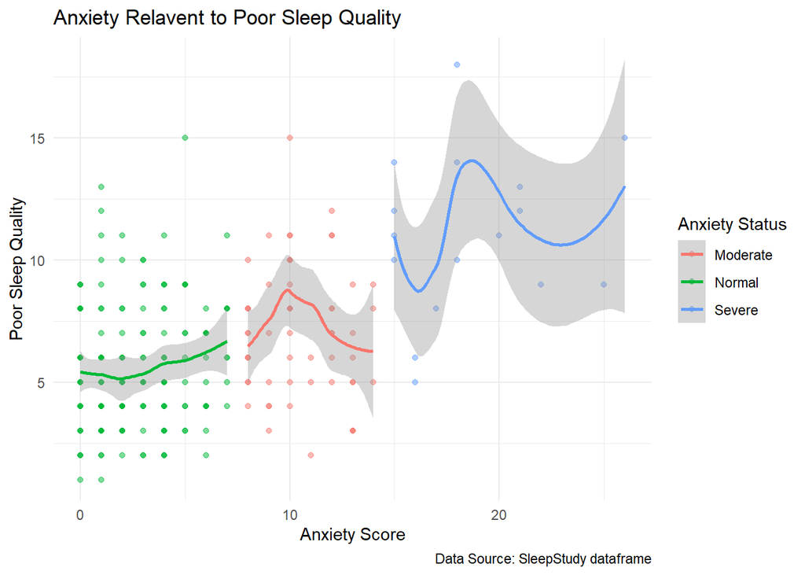

```r
ggplot(SleepStudy, aes(x = AnxietyScore, y = PoorSleepQuality, color = AnxietyStatus)) +
  geom_point(alpha = 0.5) +
  geom_smooth() +
  theme_minimal() +
  labs(x = "Anxiety Score",
       y = "Poor Sleep Quality",
       color ="Anxiety Status",
       caption = "Data Source: SleepStudy dataframe",
       title = "Anxiety Relavent to Poor Sleep Quality")
```

##### Stress

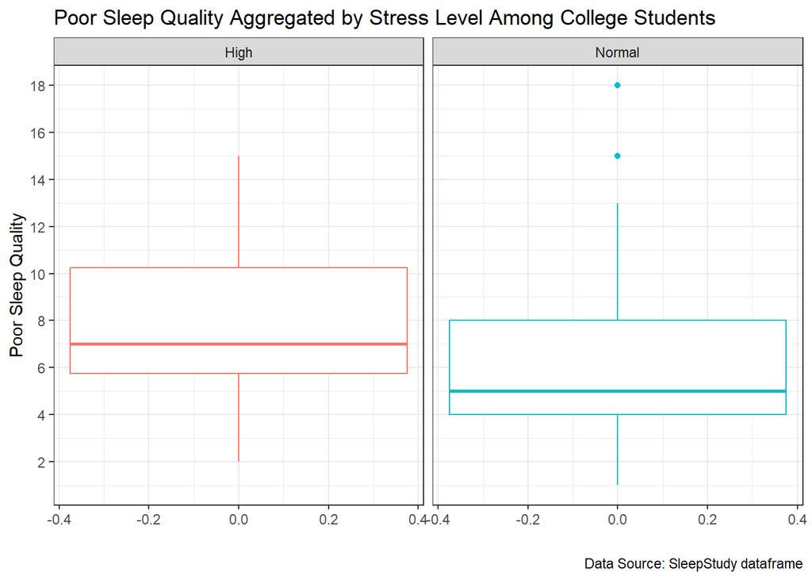

```r
SleepStudy %>%
  ggplot() +
  geom_boxplot(aes(y = PoorSleepQuality, color = Stress)) +
  scale_y_continuous(breaks = seq(0, 20, by = 2)) +
  facet_wrap(vars(Stress)) +
  theme_bw() +
  theme(legend.position = "none") +
  labs(x = "",
       y = "Poor Sleep Quality",
       caption = "Data Source: SleepStudy dataframe",
       title = "Poor Sleep Quality Aggregated by Stress Level Among College Students")
```

Furthermore, the scatterplot visually represents this correlation of approximately 0.328, emphasizing the impact of stress on the sleep experiences of the surveyed individuals.

```r
cor.test(SleepStudy$PoorSleepQuality, SleepStudy$StressScore)
```

```
##
##  Pearson's product-moment correlation
##
## data:  SleepStudy$PoorSleepQuality and SleepStudy$StressScore
## t = 5.4931, df = 251, p-value = 9.678e-08
## alternative hypothesis: true correlation is not equal to 0
## 95 percent confidence interval:
##  0.2128593 0.4334056
## sample estimates:
##       cor
## 0.3275876
```

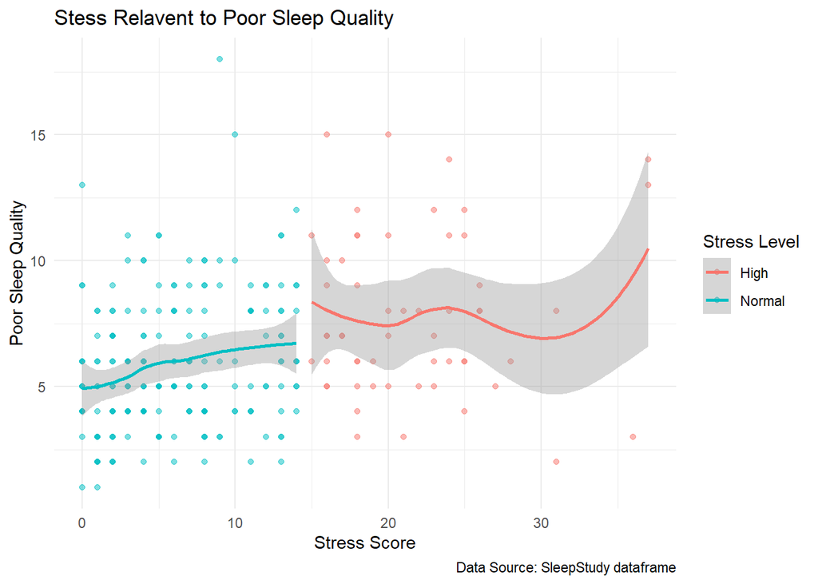

```r
ggplot(SleepStudy, aes(x = StressScore, y = PoorSleepQuality, color = Stress)) +
  geom_point(alpha = 0.5) +
  geom_smooth() +
  theme_minimal() +
  labs(x = "Stress Score",
       y = "Poor Sleep Quality",
       color ="Stress Level",
       caption = "Data Source: SleepStudy dataframe",
       title = "Stess Relavent to Poor Sleep Quality")
```

#### Alcohol

Investigating the relationship between alcohol consumption and `PoorSleepQuality`, our refined analysis accounts for variations in self-reported drinking labels. The boxplot illustrates a nuanced pattern, suggesting that while there is some variation, the level of alcohol use alone may not be a robust predictor of `PoorSleepQuality`.

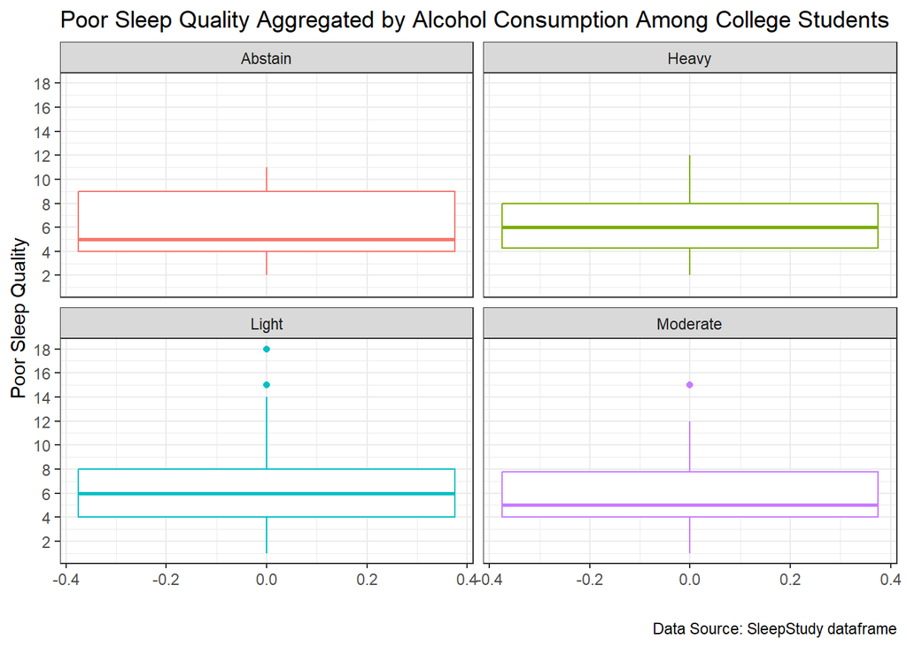

```r
AlcoholUse_Refined %>%
  ggplot() +
  geom_boxplot(aes(y = PoorSleepQuality, color = AlcoholUse_Refined)) +
  scale_y_continuous(breaks = seq(0, 20, by = 2)) +
  facet_wrap(vars(AlcoholUse_Refined)) +
  theme_bw() +
  theme(legend.position = "none") +
  labs(x = "",
       y = "Poor Sleep Quality",
       caption = "Data Source: SleepStudy dataframe",
       title = "Poor Sleep Quality Aggregated by Alcohol Consumption Among College Students")
```

A scatter plot and regression line reinforce this observation, showing scattered data points and a weak correlation between the quantity of alcoholic beverages consumed and `PoorSleepQuality`. After conducting a correlation test between `PoorSleepQuality` and `Drinks`, it was discovered that there is a slight negative correlation. However, with a correlation score of approximately -0.002, the quantity of alcoholic beverages consumed on a weekly basis does not demonstrate a significant influence upon sleep quality among college students.

```r
cor.test(SleepStudy$PoorSleepQuality, SleepStudy$Drinks)
```

```
##
##  Pearson's product-moment correlation
##
## data:  SleepStudy$PoorSleepQuality and SleepStudy$Drinks
## t = -0.031527, df = 251, p-value = 0.9749
## alternative hypothesis: true correlation is not equal to 0
## 95 percent confidence interval:
##  -0.1252872  0.1213678
## sample estimates:
##          cor
## -0.001989989
```

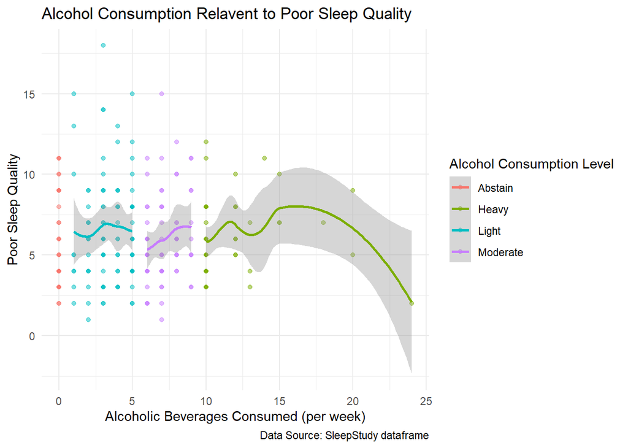

```r
ggplot(AlcoholUse_Refined, aes(x = Drinks, y = PoorSleepQuality, color = AlcoholUse_Refined)) +
  geom_point(alpha = 0.5) +
  geom_smooth() +
  theme_minimal() +
  labs(x = "Alcoholic Beverages Consumed (per week)",
       y = "Poor Sleep Quality",
       color ="Alcohol Consumption Level",
       caption = "Data Source: SleepStudy dataframe",
       title = "Alcohol Consumption Relavent to Poor Sleep Quality")
```

#### Academic Factors

In our comprehensive exploration of college students’ sleep quality, we turn our attention to academic factors. This segment of our analysis delves into the potential impact of academic performance, class attendance, course schedules, and other educational variables on the sleep patterns of the surveyed students. By examining these academic factors, we aim to discern any noteworthy correlations or trends that may shed light on the intricate relationship between academic experiences and sleep quality in the college environment.

##### GPA

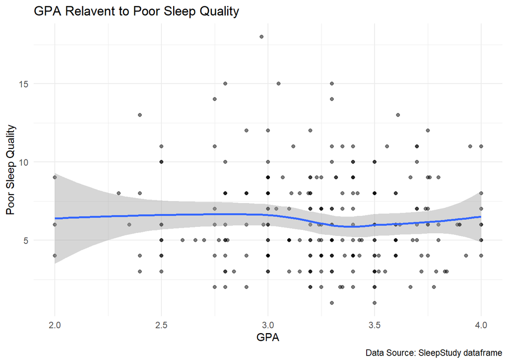

```r
ggplot(AlcoholUse_Refined, aes(x = GPA, y = PoorSleepQuality)) +
  geom_point(alpha = 0.5) +
  geom_smooth() +
  theme_minimal() +
  labs(x = "GPA",
       y = "Poor Sleep Quality",
       caption = "Data Source: SleepStudy dataframe",
       title = "GPA Relavent to Poor Sleep Quality")
```

##### Classes Missed

The exploration extends to the number of classes missed and its impact on sleep quality. The scatterplot indicates that students who miss more classes tend to experience poorer sleep quality, highlighting a potential connection between attendance, academic engagement, and sleep disturbances. With a positive correlation score of approximately 0.299, the data suggests that as the quantity of classes missed increases, the quality of sleep worsens.

```r
cor.test(SleepStudy$PoorSleepQuality, SleepStudy$ClassesMissed)
```

```
##
##  Pearson's product-moment correlation
##
## data:  SleepStudy$PoorSleepQuality and SleepStudy$ClassesMissed
## t = 4.9605, df = 251, p-value = 1.297e-06
## alternative hypothesis: true correlation is not equal to 0
## 95 percent confidence interval:
##  0.1821851 0.4071247
## sample estimates:
##       cor
## 0.2987995
```

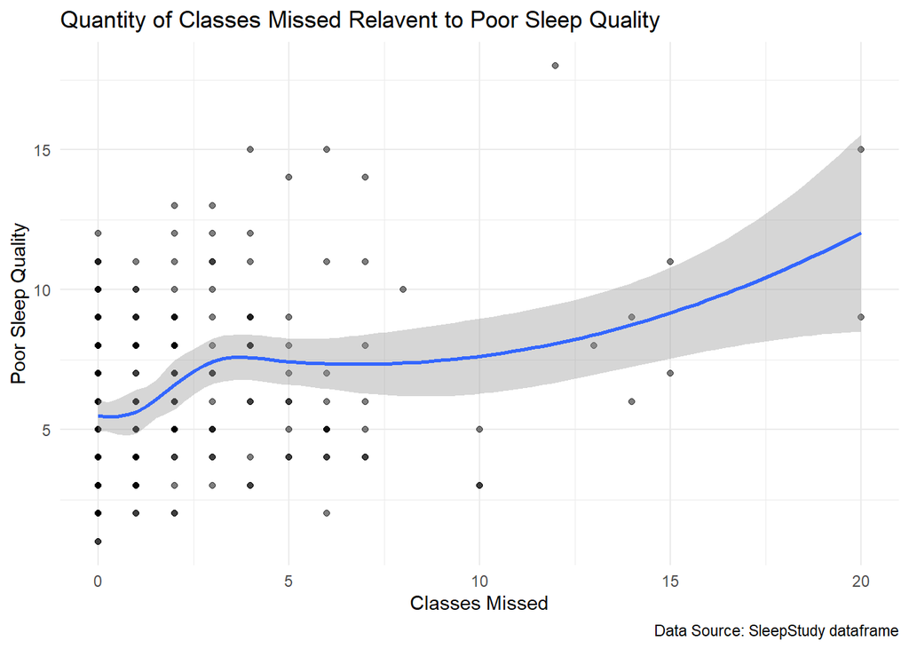

```r
ggplot(AlcoholUse_Refined, aes(x = ClassesMissed, y = PoorSleepQuality)) +
  geom_point(alpha = 0.5) +
  geom_smooth() +
  theme_minimal() +
  labs(x = "Classes Missed",
       y = "Poor Sleep Quality",
       caption = "Data Source: SleepStudy dataframe",
       title = "Quantity of Classes Missed Relavent to Poor Sleep Quality")
```

##### Early Classes

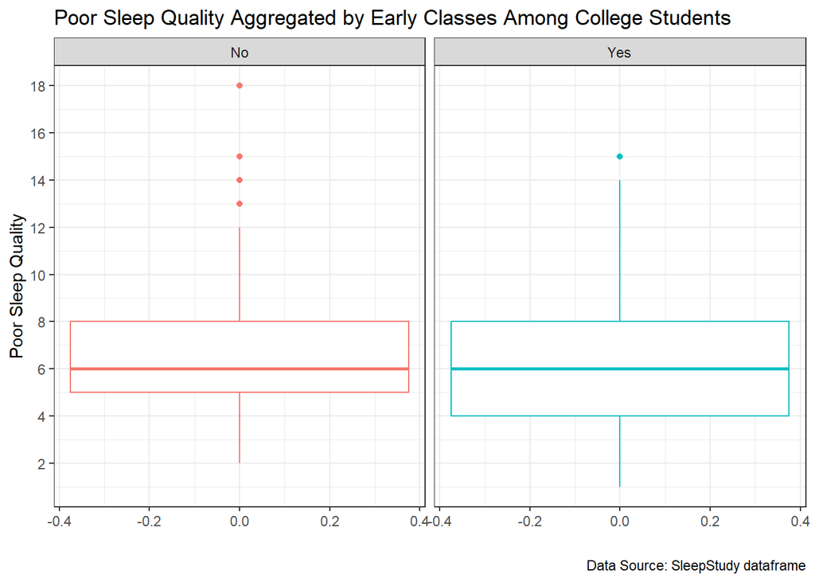

```r
SleepStudy %>%
  ggplot() +
  geom_boxplot(aes(y = PoorSleepQuality, color = EarlyClass)) +
  scale_y_continuous(breaks = seq(0, 20, by = 2)) +
  facet_wrap(vars(EarlyClass)) +
  theme_bw() +
  theme(legend.position = "none") +
  labs(x = "",
       y = "Poor Sleep Quality",
       caption = "Data Source: SleepStudy dataframe",
       title = "Poor Sleep Quality Aggregated by Early Classes Among College Students")
```

##### All-nighters

Analyzing the impact of all-nighters on sleep quality, the boxplot indicates that students who pull all-nighters tend to have poorer sleep quality. This aligns with common expectations, highlighting the toll that staying awake through the night can take on the overall sleep experiences of college students.

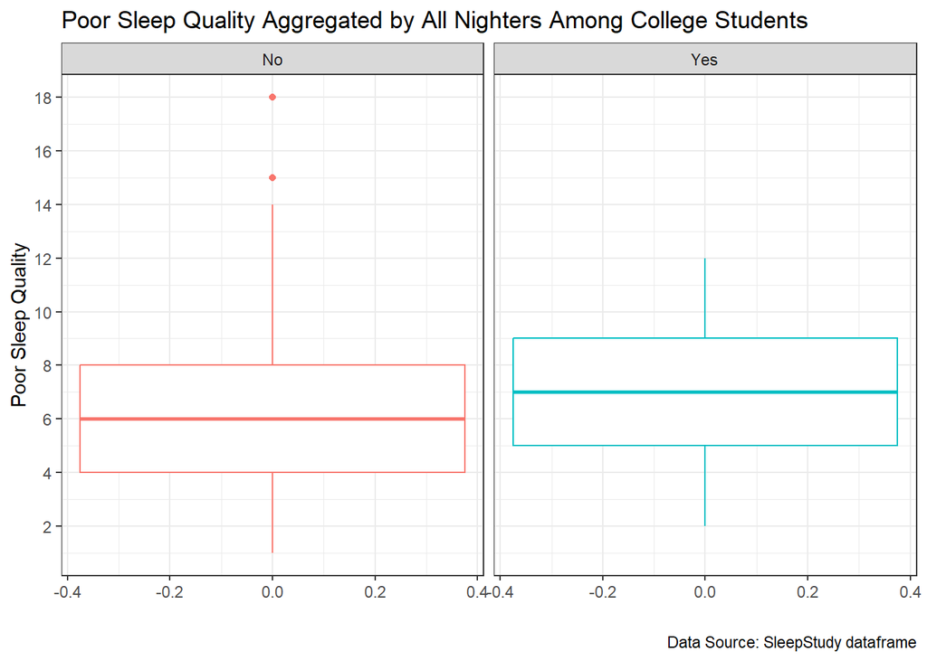

```r
SleepStudy %>%
  ggplot() +
  geom_boxplot(aes(y = PoorSleepQuality, color = AllNighter)) +
  scale_y_continuous(breaks = seq(0, 20, by = 2)) +
  facet_wrap(vars(AllNighter)) +
  theme_bw() +
  theme(legend.position = "none") +
  labs(x = "",
       y = "Poor Sleep Quality",
       caption = "Data Source: SleepStudy dataframe",
       title = "Poor Sleep Quality Aggregated by All Nighters Among College Students")
```

### Quantity of Sleep by Cognitive Function Scores

Continuing our investigation into sleep quality among college students, we shift our focus to the Quantity of Sleep by Cognitive Function Scores. This aspect of our analysis explores the potential correlation between the number of hours slept and cognitive function scores on skill tests. By examining these variables, we aim to gain insights into the relationship between sleep duration and cognitive performance, providing a better understanding of the factors influencing the cognitive abilities of the surveyed individuals.

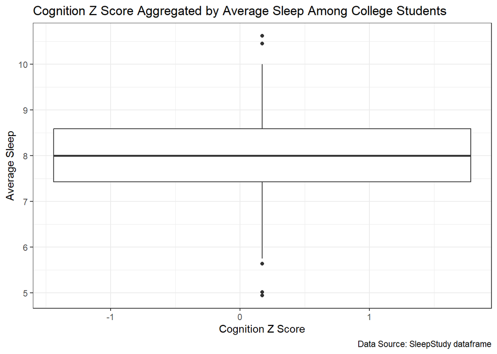

```r
SleepStudy %>%
  ggplot(aes(x = CognitionZscore, y = AverageSleep)) +
  geom_boxplot() +
  theme_bw() +
  labs(x = "Cognition Z Score",
       y = "Average Sleep",
       caption = "Data Source: SleepStudy dataframe",
       title = "Cognition Z Score Aggregated by Average Sleep Among College Students")
```

Examining the relationship between the quantity of sleep and cognitive function scores, a correlation test was conducted. The test resulted in a correlation coefficient of -0.0239. Based on this correlation coefficient, it indicates a very slight negative correlation between the average hours of sleep and cognitive function scores. However, this correlation is so close enough to zero that it may suggest a weak relationship. In statistical terms, the correlation is not statistically significant, as evidenced by the p-value of 0.7057, which is greater than the commonly used significance level of 0.05.

```r
cor.test(SleepStudy$AverageSleep, SleepStudy$CognitionZscore)
```

```
##
##  Pearson's product-moment correlation
##
## data:  SleepStudy$AverageSleep and SleepStudy$CognitionZscore
## t = -0.37803, df = 251, p-value = 0.7057
## alternative hypothesis: true correlation is not equal to 0
## 95 percent confidence interval:
##  -0.14675050  0.09976723
## sample estimates:
##         cor
## -0.02385425
```

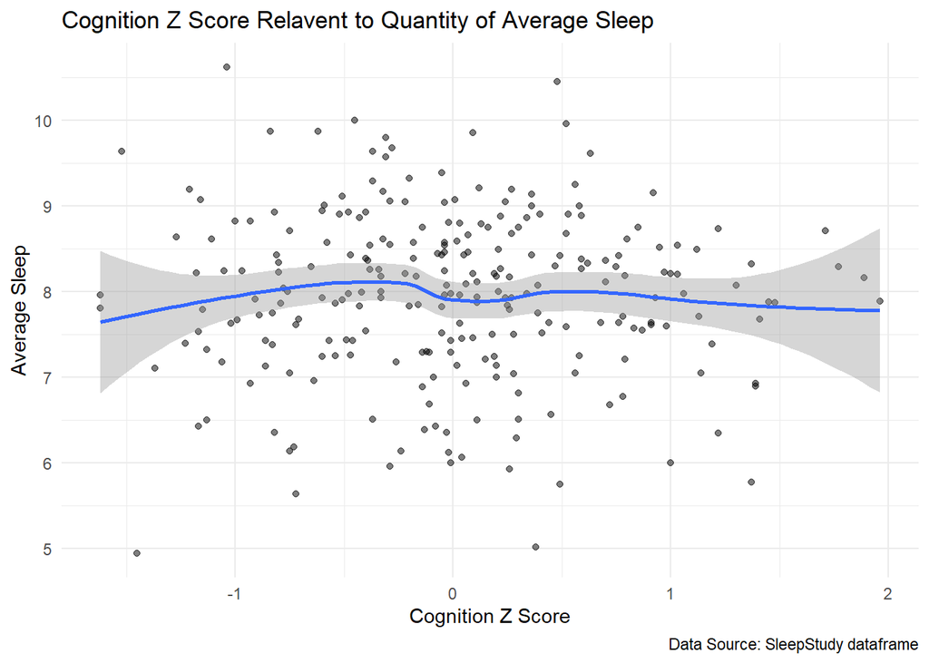

```r
ggplot(SleepStudy, aes(x = CognitionZscore, y = AverageSleep)) +
  geom_point(alpha = 0.5) +
  geom_smooth() +
  theme_minimal() +
  labs(x = "Cognition Z Score",
       y = "Average Sleep",
       caption = "Data Source: SleepStudy dataframe",
       title = "Cognition Z Score Relavent to Quantity of Average Sleep")
```